# Tugas Pertemuan 3 MPDW

Yasmin Aufaahani Abdullah-M0401241129

2026-09-09

```r
library(dLagM)
library(dynlm)
library(MLmetrics)
library(lmtest)
library(car)
```

# INPUT DATA

```r
data <- read.csv("C://Users//User//Downloads//NewDelhi_Air_quality.csv", sep = ";")
data
```

```
##     X  AQI         CO      datetime        no2         o3        pm10
## 1   0 30.2 19.860.268 2022-10-21:18 0.04685717 55.789.948  10.486.722
## 2   1 28.2 19.760.132 2022-10-21:19 0.04645554  5.493.164  10.719.325
## 3   2 26.6 19.860.268 2022-10-21:20 0.04685717  5.464.554  11.155.578
## 4   3 25.0 20.194.054 2022-10-21:21 0.04819594  5.507.469  11.116.206
## 5   4 26.0  2.052.784 2022-10-21:22 0.04886533 55.789.948   1.040.525
## 6   5 26.0 20.861.626 2022-10-21:23 0.05020411 56.505.203   9.402.518
## 7   6 26.0 20.861.626 2022-10-22:00 0.05020411 55.789.948   8.482.822
## 8   7 24.0  2.052.784 2022-10-22:01 0.05020411 52.928.925  75.866.675
## 9   8 23.0  2.002.716 2022-10-22:02 0.04685717    500.679  76.365.867
## 10  9 24.0 19.693.375 2022-10-22:03 0.04417961 51.498.413   8.487.648
## 11 10 25.0 19.860.268 2022-10-22:04 0.04284084  5.364.418   9.357.371
## 12 11 26.0  2.002.716 2022-10-22:05 0.04049798 55.789.948  10.338.728
## 13 12 27.0 20.360.947 2022-10-22:06 0.04016329 59.366.226 105.233.135
## 14 13 29.0  2.052.784 2022-10-22:07 0.03882451  6.222.725   1.063.597
```

[output cut: 131 more lines]

```r
fix_number <- function(x){
  as.numeric(gsub("\\.", "",x))/1e6
}

data <- data.frame(
  datetime=as.POSIXct(data$datetime,format="%Y-%m-%d:%H", tz="UTC"),
  AQI = as.numeric(data$AQI),
  CO = fix_number(data$CO),
  NO2= as.numeric(data$no2),
  O3 = fix_number(data$o3),
  PM10 = fix_number(data$pm10),
  PM25= fix_number(data$pm25),
  SO2=as.numeric(data$so2)
)
```

```r
#mengurutkan data berdasarkan waktu
data <- data[order(data$datetime), ]
data<- na.omit (data)
str(data)
```

```
## 'data.frame':    72 obs. of  8 variables:
##  $ datetime: POSIXct, format: "2022-10-21 18:00:00" "2022-10-21 19:00:00" ...
##  $ AQI     : num  30.2 28.2 26.6 25 26 26 26 24 23 24 ...
##  $ CO      : num  19.86 19.76 19.86 20.19 2.05 ...
##  $ NO2     : num  0.0469 0.0465 0.0469 0.0482 0.0489 ...
##  $ O3      : num  55.79 5.49 5.46 5.51 55.79 ...
##  $ PM10    : num  10.49 10.72 11.16 11.12 1.04 ...
##  $ PM25    : num  56.37 4.62 3.52 22.26 19.79 ...
##  $ SO2     : num  0.387 0.41 0.402 0.376 0.339 ...
```

```r
# Variabel x dan Y
model_data <- data.frame(Yt = data$AQI, Xt=data$PM25)
```

# Bagi Data Trining & Testing

```r
n <-nrow(model_data)
train_n<-round(0.85*n)
test_n<-n-train_n
```

```r
train<-model_data[1:train_n, ]
test <- model_data[(train_n+1):n, ]

train.ts<- ts(train)
test.ts<- ts(test)
data.ts<-ts(model_data)
```

# MODEL KOYCK

## Pemodelan

```r
model.koyck<- koyckDlm(x=train$Xt, y = train$Yt)
summary(model.koyck)
```

```
##
## Call:
## "Y ~ (Intercept) + Y.1 + X.t"
##
## Residuals:
##      Min       1Q   Median       3Q      Max
## -2.04091 -0.74445  0.07571  0.64727  2.15786
##
## Coefficients:
##             Estimate Std. Error t value Pr(>|t|)
## (Intercept)  0.91518    1.68165   0.544    0.588
## Y.1          0.93357    0.10434   8.947 1.88e-12 ***
## X.t          0.04589    0.10348   0.443    0.659
## ---
## Signif. codes:  0 '***' 0.001 '**' 0.01 '*' 0.05 '.' 0.1 ' ' 1
##
## Residual standard error: 1.006 on 57 degrees of freedom
## Multiple R-Squared: 0.8468,  Adjusted R-squared: 0.8414
## Wald test: 159.4 on 2 and 57 DF,  p-value: < 2.2e-16
##
## Diagnostic tests:
## NULL
##
##                             alpha       beta       phi
## Geometric coefficients:  13.77704 0.04589049 0.9335722
```

$Y_t-1$ memiliki nilai $p-value$ sebesar 1.88e-12 < 0.05, artinya nilai variabel Y periode sebelumnya berpengaruh sangat kuat terhadap nilai Y periode sekarang. Sedangkan $X_t$ memiliki nilai $p-value$ sebesar 0.659 > 0.05, yang artinya Nilai X saat ini tidak memiliki pengaruh langsung terhadap Y.Dalam pemodelan ini pun, didapatkan $R^2$ sebesar 0.8469 yang artinya model mampu menjelaskan sebesar 84.68% variasi dari $Y_t$. Adapun persamaan model ini adalah :
$$\hat{Y}_t = 0.91518 + 0.9336 Y_{t-1} +
0.0459 X_t$$
## Peramalan

```r
fore.koyck <- forecast(model = model.koyck, x=test$Xt, h = test_n)
fore.koyck
```

```
## $forecasts
##  [1] 21.01775 20.67858 21.58598 22.37370 21.92985 22.64148 22.17747 22.86451
##  [9] 23.51965 24.14823 24.71939
##
## $call
## forecast.koyckDlm(model = model.koyck, x = test$Xt, h = test_n)
##
## attr(,"class")
## [1] "forecast.koyckDlm" "dLagM"
```

## AKURASI

```r
# MAPE
mape.koyck <- MAPE(fore.koyck$forecasts, test$Yt)
cat("mape koyck:", mape.koyck, "\n")
```

```
## mape koyck: 0.07593307
```

```r
# deviance
get_deviance <- function(model){
  sum(residuals(model)^2, na.rm = TRUE)
}

dev.koyck<- get_deviance(model.koyck$model)
cat ("Deviance Model Koyck:", dev.koyck, "\n")
```

```
## Deviance Model Koyck: 57.71585
```

# Distributed Lag Model (DLM)

## Lag Optimum

```r
q_max <- 10
dlm_auto <- finiteDLMauto(
  formula = Yt ~ Xt,
  data = data.frame(train),
  q.min = 1, q.max= q_max,
  model.type = "dlm", error.type="AIC", trace = TRUE
)
dlm_auto
```

```
##    q - k    MASE      AIC      BIC    GMRAE    MBRAE R.Adj.Sq    Ljung-Box
## 10    10 2.43061 240.3525 265.4662 37531.98  0.59554  0.24014 1.938528e-08
## 9      9 2.65443 246.7886 270.2036 37466.28  1.22325  0.20562 3.177482e-07
## 8      8 2.76068 255.9027 277.5759 28996.94  0.69307  0.14277 2.219471e-08
## 7      7 2.74828 260.8636 280.7535 24977.13  1.08279  0.12801 2.710666e-09
## 6      6 2.63934 264.3479 282.4139 19932.03  1.03294  0.11896 1.294304e-09
## 5      5 2.70269 268.9372 285.1400 21757.34 -0.31753  0.09158 6.595724e-10
## 4      4 2.75799 271.6717 285.9731 26049.38  0.66628  0.09355 1.289784e-10
## 3      3 2.72245 273.7459 286.1085 22301.80  1.36561  0.11106 6.067735e-11
## 2      2 2.62506 275.3591 285.7467 19333.12  1.89502  0.12681 4.465928e-11
## 1      1 2.63633 279.5779 287.9552 16999.28  2.66125  0.10791 1.440353e-10
```

```r
q_opt<-dlm_auto[which.min(dlm_auto$AIC), "q - k"]
cat("Lag Optimum DLM (q):", q_opt, "\n")
```

```
## Lag Optimum DLM (q): 10
```

## Membangun ulang model DLM dengan Lag optimum

```r
model.dlm.opt<- dlm(x=train$Xt, y = train$Yt, q = q_opt)
summary(model.dlm.opt)
```

```
##
## Call:
## lm(formula = model.formula, data = design)
##
## Residuals:
##     Min      1Q  Median      3Q     Max
## -6.1274 -0.8884  0.2148  1.1393  3.5094
##
## Coefficients:
##             Estimate Std. Error t value Pr(>|t|)
## (Intercept) 17.60240    2.53254   6.950 2.51e-08 ***
## x.t          0.14132    0.04554   3.103  0.00355 **
## x.1          0.12884    0.04486   2.872  0.00656 **
## x.2          0.07580    0.04509   1.681  0.10073
## x.3          0.02608    0.04622   0.564  0.57579
## x.4          0.03746    0.04739   0.790  0.43404
## x.5          0.06249    0.04760   1.313  0.19697
## x.6          0.05673    0.04724   1.201  0.23698
## x.7          0.03555    0.04875   0.729  0.47023
## x.8          0.04544    0.04843   0.938  0.35383
## x.9          0.02131    0.04817   0.442  0.66066
## x.10        -0.03003    0.03907  -0.769  0.44669
## ---
## Signif. codes:  0 '***' 0.001 '**' 0.01 '*' 0.05 '.' 0.1 ' ' 1
##
## Residual standard error: 2.263 on 39 degrees of freedom
## Multiple R-squared:  0.4073, Adjusted R-squared:  0.2401
## F-statistic: 2.437 on 11 and 39 DF,  p-value: 0.02016
##
## AIC and BIC values for the model:
##        AIC      BIC
## 1 240.3525 265.4662
```

Didapatkan nilaii $p-value$ sebesar 0.02016 < 0.05, artinya simultan secara bersama-sama, variabel x pada periode yang berjalan beserta seluruh lagnya berpengaruh signifikan terhadap variabel y. Selain itu, didapatkan pula nilai $R^2$ sebesar 0.4073, yang artinya model mampu menjelaskan 40.73% variasi dari variabel y. Terlihat pula hanya $x_t$ dan $x_t-1$ yang berpengaruh signifikan, sedangkan $x_t-2$ hingga $x_t-10$ tidak berpengaruh signifikan. Kondisi dominasi lag yang tidak signifikan ini merupakan indikasi adanya multikolinearitas yang tinggi antar variabel lag x. ## Peramalan

```r
fore.dlm.opt<- forecast(model=model.dlm.opt, x=test$Xt, h= test_n)
```

## AKURASI

```r
# MAPE
mape.dlm <- MAPE(fore.dlm.opt$forecasts, test$Yt)
mape.dlm
```

```
## [1] 0.2673498
```

```r
dev.dlm <- get_deviance(model.dlm.opt$model)
dev.dlm
```

```
## [1] 199.7244
```

# Model Autoregressive Distributed Lag (ARDL)

## Kombinasi lag optimum

```r
p_max<-4
q_max_ardl<-4
model.ardl.search<- ardlBoundOrders(
  data = data.frame(model_data), ic = "AIC",
  formula = Yt ~ Xt, max.p = p_max, max.q = q_max_ardl
)
```

```r
min_p<-c()
for(i in 1:q_max_ardl){
  min_p[i]<-min(model.ardl.search$Stat.table[[i]])
}
q_opt_ardl <- which(min_p == min(min_p, na.rm = TRUE))
p_opt_ardl <- which(
  model.ardl.search$Stat.table[[q_opt_ardl]] ==
    min(model.ardl.search$Stat.table[[q_opt_ardl]], na.rm = TRUE)
)
data.frame("Lag_Y_opt(q)" = q_opt_ardl,
           "Lag_X_opt(p)" = p_opt_ardl,
           "AIC" = model.ardl.search$min.Stat)
```

```
##   Lag_Y_opt.q. Lag_X_opt.p.      AIC
## 1            1            4 167.0204
```

## Membangun model ARDL dengan lag optimum

```r
model.ardl <- ardlDlm(formula=Yt~Xt, data = train,
                      p = p_opt_ardl, q=q_opt_ardl)
summary(model.ardl)
```

```
##
## Time series regression with "ts" data:
## Start = 5, End = 61
##
## Call:
## dynlm(formula = as.formula(model.text), data = data)
##
## Residuals:
##     Min      1Q  Median      3Q     Max
## -2.1373 -0.7230  0.1116  0.4268  2.1442
##
## Coefficients:
##              Estimate Std. Error t value Pr(>|t|)
## (Intercept) -0.100653   1.430032  -0.070    0.944
## Xt.t         0.005504   0.017405   0.316    0.753
## Xt.1        -0.005281   0.017420  -0.303    0.763
## Xt.2        -0.010319   0.017401  -0.593    0.556
## Xt.3        -0.028628   0.017232  -1.661    0.103
## Xt.4         0.007226   0.014384   0.502    0.618
## Yt.1         1.018776   0.058544  17.402   <2e-16 ***
## ---
## Signif. codes:  0 '***' 0.001 '**' 0.01 '*' 0.05 '.' 0.1 ' ' 1
##
## Residual standard error: 0.9323 on 50 degrees of freedom
## Multiple R-squared:  0.883,  Adjusted R-squared:  0.869
## F-statistic:  62.9 on 6 and 50 DF,  p-value: < 2.2e-16
```

Didapatkan nilai $p-value$ sebesar 2.2e-16 < 0.05, yang artinya seluruh variabel X secara simultan berpengaruh signifikan terhadap Y. Didapatkan pula nilai $R^2$ sebesar 0.883 yang artinya sebesar 88.3% variasi dari variabel $Y_t$ dapat dijelaskan oleh model. ## Peramalan

```r
fore.ardl<- forecast(model=model.ardl,x=test$Xt, h = test_n)
```

## Akurasi

```r
# MAPE
mape.ardl <-MAPE(fore.ardl$forecasts, test$Yt)
mape.ardl
```

```
## [1] 0.1658645
```

```r
# Deviance
dev.ardl <- get_deviance(model.ardl$model)
dev.ardl
```

```
## [1] 43.45752
```

# Uji Asumsi Model (Menggunakan model dynlm)

## Model setara DLM & ARDL menggunakan dynlm

```r
cons_lm_dlm  <- dynlm(Yt ~ Xt + L(Xt, 1:q_opt), data = train.ts)
cons_lm_ardl <- dynlm(Yt ~ Xt + L(Xt, 1:p_opt_ardl) + L(Yt, 1:q_opt_ardl),
                       data = train.ts)
```

## Uji Autokorelasi

```r
dwtest(cons_lm_dlm)
```

```
##
##  Durbin-Watson test
##
## data:  cons_lm_dlm
## DW = 0.40975, p-value = 1.446e-11
## alternative hypothesis: true autocorrelation is greater than 0
```

```r
dwtest(cons_lm_ardl)
```

```
##
##  Durbin-Watson test
##
## data:  cons_lm_ardl
## DW = 1.0265, p-value = 3.107e-05
## alternative hypothesis: true autocorrelation is greater than 0
```

Hasil dari uji autokorelasi didapatkan bahwa nilai p-value < 0.05, baik untuk DLM maupun ARDL. Artinya, Tolak H0 atau kedua model masih mengalami autokorelasi. ## Uji Heteroskedastisitas

```r
bptest(cons_lm_dlm)
```

```
##
##  studentized Breusch-Pagan test
##
## data:  cons_lm_dlm
## BP = 3.1153, df = 11, p-value = 0.9891
```

```r
bptest(cons_lm_ardl)
```

```
##
##  studentized Breusch-Pagan test
##
## data:  cons_lm_ardl
## BP = 4.1209, df = 6, p-value = 0.6603
```

Didapatkan nilai 0-value > 0.05, yang artinya Gagal tolak H0. Hal ini menunjukkan bahwa ragam sisaan bersifat homogen / bersifat homoskedastisitas ## Uji Normalitas Residual (Shapiro Wilk)

```r
shapiro.test(residuals(cons_lm_dlm))
```

```
##
##  Shapiro-Wilk normality test
##
## data:  residuals(cons_lm_dlm)
## W = 0.9568, p-value = 0.06097
```

```r
shapiro.test(residuals(cons_lm_ardl))
```

```
##
##  Shapiro-Wilk normality test
##
## data:  residuals(cons_lm_ardl)
## W = 0.97451, p-value = 0.27
```

Didapatkan nilai p-value > 0.05, artinya gagal tolak H0. artinya sisaan kedua model berdistribusi normal. # Perbandingan Performa Model ## AKURASI

```r
akurasi <- data.frame(
  Model    = c("Koyck", "DLM Optimum", "ARDL Optimum"),
  Lag      = c("q=NA (geometric)",
               paste0("q=", q_opt),
               paste0("p=", p_opt_ardl, ", q=", q_opt_ardl)),
  MAPE     = c(mape.koyck, mape.dlm, mape.ardl),
  Deviance = c(dev.koyck, dev.dlm, dev.ardl)
)
print(akurasi)
```

```
##          Model              Lag       MAPE  Deviance
## 1        Koyck q=NA (geometric) 0.07593307  57.71585
## 2  DLM Optimum             q=10 0.26734981 199.72443
## 3 ARDL Optimum         p=4, q=1 0.16586445  43.45752
```

```r
model_terbaik <- akurasi$Model[which.min(akurasi$MAPE)]
cat("\nModel terbaik berdasarkan MAPE adalah:", model_terbaik, "\n")
```

```
##
## Model terbaik berdasarkan MAPE adalah: Koyck
```

## Visualisasi Perbandingan hasil peramalan

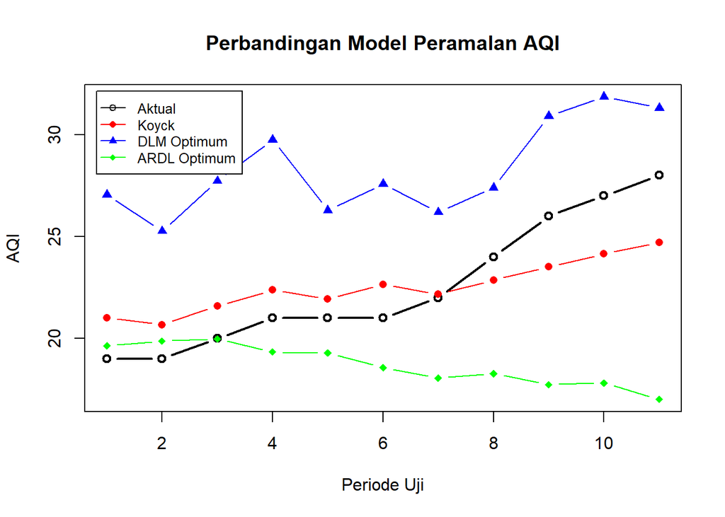

```r
par(mfrow = c(1, 1))
plot(1:test_n, test$Yt, type = "b", col = "black", lwd = 2, pch = 1,
     ylim = range(c(test$Yt, fore.koyck$forecasts,
                     fore.dlm.opt$forecasts, fore.ardl$forecasts)),
     xlab = "Periode Uji", ylab = "AQI",
     main = "Perbandingan Model Peramalan AQI")

lines(1:test_n, fore.koyck$forecasts,   col = "red",   type = "b", pch = 16)
lines(1:test_n, fore.dlm.opt$forecasts, col = "blue",  type = "b", pch = 17)
lines(1:test_n, fore.ardl$forecasts,    col = "green", type = "b", pch = 18)

legend("topleft",
       legend = c("Aktual", "Koyck", "DLM Optimum", "ARDL Optimum"),
       col = c("black", "red", "blue", "green"),
       lty = 1, pch = c(1, 16, 17, 18), cex = 0.8, inset = 0.02)
```